# Data Cleaning and Management

Crime Analytics (CJUS 6106)

## Data: Care and Feeding

How do we actually change the data we *have* into the data we *need*.

Most of the heavy lifting involved in data analytics is really a process of data cleaning and data transformation. Running statistical models or hypothesis tests doesn’t take very much time (or code), once you have the data in the form you need. Getting the data to that stage is the trick.

This lesson will go over these essential data management skills:

- Data merging
- Data transformation
- Data recoding

We’ll be using data on drug seizures from a large sample of countries between 1980 and 2006. The data are stored in two files:

- A file that has demographic data (population, region) for each country
- A file that has drug seizure amount (in kg) for four substances
  - Cannabis
  - Cocaine
  - Heroin
  - Opium

The first thing we need to do is pull those two data sets into R’s memory.

```r
demographics <- read.csv("UNODC Drug Seizure Data Pt 1.csv")

seizures <- read.csv("UNODC Drug Seizure Data Pt 2.csv")

str(demographics)
```

```
## 'data.frame':    5400 obs. of  4 variables:
##  $ Country   : chr  "Burundi" "Burundi" "Burundi" "Burundi" ...
##  $ Year      : int  1980 1981 1982 1983 1984 1985 1986 1987 1988 1989 ...
##  $ Region    : chr  "Africa" "Africa" "Africa" "Africa" ...
##  $ Population: num  4127 4240 4359 4487 4625 ...
```

```r
str(seizures)
```

```
## 'data.frame':    5400 obs. of  6 variables:
##  $ Country : chr  "Burundi" "Burundi" "Burundi" "Burundi" ...
##  $ Year    : int  1980 1981 1982 1983 1984 1985 1986 1987 1988 1989 ...
##  $ Cannabis: num  0 0 0 0 0 0 0 0 1500 0 ...
##  $ Cocaine : num  0 0 0 0 0 0 0 0 0 0 ...
##  $ Heroin  : num  0 0 0 0 0 0 0 0 0 0 ...
##  $ Opium   : num  0 0 0 0 0 0 0 0 0 0 ...
```

Both the **Country** and **Year** variables are present in both data sets. We need to pull those two together, merging them.

## Merging data

Merging the data by a common variable requires the merge() function.

```r
drugs <- merge(demographics,seizures, by="Country")
str(drugs)
```

```
## 'data.frame':    145800 obs. of  9 variables:
##  $ Country   : chr  "Afghanistan" "Afghanistan" "Afghanistan" "Afghanistan" ...
##  $ Year.x    : int  1980 1980 1980 1980 1980 1980 1980 1980 1980 1980 ...
##  $ Region    : chr  "Asia" "Asia" "Asia" "Asia" ...
##  $ Population: num  13180 13180 13180 13180 13180 ...
##  $ Year.y    : int  1980 1981 1982 1983 1984 1985 1986 1987 1988 1989 ...
##  $ Cannabis  : num  0 0 0 0 0 0 0 0 0 0 ...
##  $ Cocaine   : num  0 0 0.145 4.256 24 ...
##  $ Heroin    : num  0.03 41.52 9.29 446.33 102.61 ...
##  $ Opium     : num  5771 10617 7473 16416 5476 ...
```

That looks like it works at first glance, but **Year** is repeated…. *27 times*. And the length is way off!

We can actually merge by two variables.

```r
drugs <- merge(demographics, seizures, by=c("Country","Year"))
str(drugs)
```

```
## 'data.frame':    5400 obs. of  8 variables:
##  $ Country   : chr  "Afghanistan" "Afghanistan" "Afghanistan" "Afghanistan" ...
##  $ Year      : int  1980 1981 1982 1983 1984 1985 1986 1987 1988 1989 ...
##  $ Region    : chr  "Asia" "Asia" "Asia" "Asia" ...
##  $ Population: num  13180 12964 12634 12242 11854 ...
##  $ Cannabis  : num  0 0 0 0 0 0 0 0 0 0 ...
##  $ Cocaine   : num  0 0 0.145 4.256 24 ...
##  $ Heroin    : num  0.03 41.52 9.29 446.33 102.61 ...
##  $ Opium     : num  5771 10617 7473 16416 5476 ...
```

Obviously, if you only have one common variable, just merge by that one.

## Transforming Variables

You might need to do any number of transformations, including:

- Mathematical operations (summing, subtracting, etc)
- Logarithmic transformations
- Centering variables

Anytime you go messing around with data recoding, transformations, etc., it’s a good idea to make a copy of the original variables, then tinker with the copies.

```r
mj <- drugs$Cannabis
heroin <- drugs$Heroin
coke <- drugs$Cocaine
opium <- drugs$Opium
pop <- drugs$Population
```

Now we can go to town.

### Summing variables

Let’s get the total seizures for each country.

```r
total <- mj + heroin + coke + opium
summary(total)
```

```
##    Min. 1st Qu.  Median    Mean 3rd Qu.    Max.
##       0       0      86   27026    2360 8560573
```

What if wanted to calculate a seizure rate?

Rate = how often something happens divided by the population

Example:

- Number of homicides per 100,000 population

Since we already have the population, we can use it in our calculation.

```r
szrate <- (total/pop)*100000
summary(szrate)
```

```
##      Min.   1st Qu.    Median      Mean   3rd Qu.      Max.
##         0         0      1706    761536     30409 907040102
```

### Logarithmic transformation

Logarithm - the logarithm of a number is the power to which you must raise the natural number e to produce the number itself

e = 2.718

```r
log(100)
```

```
## [1] 4.60517
```

> $e^{4.60517} = 100$

Logarithmic transformations have small effects on small numbers, and very big effects on big numbers. They’re good to use when you have a highly skewed distribution (a few really really high values)

```r
log.total <- log(total+1)
summary(log.total)
```

```
##    Min. 1st Qu.  Median    Mean 3rd Qu.    Max.
##   0.000   0.000   4.460   4.436   7.767  15.963
```

You need to add 1 to the values before you take the natural log if you have any zeroes in your data, because the natural log of zero is undefined. You can’t raise e to any power and get zero.

But the natural log of 1 is zero.

> $e^{0}=1$

```r
log(1)
```

```
## [1] 0
```

So, if you have zeroes, and you add 1, then take the natural log, those observations just go back to zero.

Neat, huh?

### Centering variables

It’s sometimes a good idea to change a variable to be centered around its mean. The interpretations are generally cleaner because you’re interpreting changes from the average case, rather than from a case with a value of zero.

The new variable, after you center it, will have a mean of zero, and all observations less that the original mean will have a negative value on the new variable, and all observations greater than the original mean will have a positive value on the new variable.

Here’s how it works.

```r
summary(total)
```

```
##    Min. 1st Qu.  Median    Mean 3rd Qu.    Max.
##       0       0      86   27026    2360 8560573
```

```r
ctr.total <- total - mean(total)
summary(ctr.total)
```

```
##    Min. 1st Qu.  Median    Mean 3rd Qu.    Max.
##  -27026  -27026  -26940       0  -24666 8533547
```

## Recoding Variables

Finally, let’s suppose you want to recode variables that you have into new variables.

There’s a variable in the data set called “Region”. The very first thing to do is look at the old variable, the original one.

```r
table(drugs$Region)
```

```
##
##   Africa Americas     Asia   Europe  Oceania
##     1458     1296     1161     1269      216
```

Let’s suppose we want to create a new variable that gives a numerical flag for each region according to this scheme.

- 1 = Africa
- 2 = Americas
- 3 = Asia
- 4 = Europe
- 5 = Oceania

The next thing to do is to create a new empty variable

```r
regioncode<-vector()
```

It’s important that the new variable has the same length as the old one. You can manually set the length to be the same. Easy.

```r
length(regioncode) <- length(drugs$Region)
```

Now we can assign the values of the new variable based on the values of the old one.

```r
regioncode[drugs$Region=="Africa"]<-1
regioncode[drugs$Region=="Americas"]<-2
regioncode[drugs$Region=="Asia"]<-3
regioncode[drugs$Region=="Europe"]<-4
regioncode[drugs$Region=="Oceania"]<-5
```

You need to use the quotation marks in the code above to tell R to look for a character string.

Lastly, look at the new variable to make sure the recoding did what you wanted it to do.

```r
table(regioncode, drugs$Region)
```

```
##
## regioncode Africa Americas Asia Europe Oceania
##          1   1458        0    0      0       0
##          2      0     1296    0      0       0
##          3      0        0 1161      0       0
##          4      0        0    0   1269       0
##          5      0        0    0      0     216
```

Note - this is just an example of **how** to do this. Generally you can just make the region variable a factor using the as.factor() function and R will assign the numbers for you but still show the category labels.

Or, maybe we want to recode an interval/ratio variable into an ordinal one.

```r
summary(total)
```

```
##    Min. 1st Qu.  Median    Mean 3rd Qu.    Max.
##       0       0      86   27026    2360 8560573
```

```r
totalbins <- vector()
length(totalbins) <- length(total)
totalbins[total >= 0 & total < 10000]<-1
totalbins[total >= 10000 & total < 50000]<-2
totalbins[total >= 50000]<-3
table(totalbins)
```

```
## totalbins
##    1    2    3
## 4658  466  276
```

## Aggregating the variables into a single data frame

Since we took the time to make all those cool new variables, we want to add them to our data set.

We want to add them as columns, since we know that each column in our tidy data should be one unique variable.

We want to bind those variables as columns to the data frame that already exists. We do this using the **cbind()** function (meaning “column bind”).

```r
drugs <- cbind(drugs,total,totalbins,szrate,ctr.total,regioncode)
```

It’s crucial to include the original data frame inside the cbind() statement! You’re replacing the old data frame with the combination of the old data frame with the addition of all the new variables.

```r
str(drugs)
```

```
## 'data.frame':    5400 obs. of  13 variables:
##  $ Country   : chr  "Afghanistan" "Afghanistan" "Afghanistan" "Afghanistan" ...
##  $ Year      : int  1980 1981 1982 1983 1984 1985 1986 1987 1988 1989 ...
##  $ Region    : chr  "Asia" "Asia" "Asia" "Asia" ...
##  $ Population: num  13180 12964 12634 12242 11854 ...
##  $ Cannabis  : num  0 0 0 0 0 0 0 0 0 0 ...
##  $ Cocaine   : num  0 0 0.145 4.256 24 ...
##  $ Heroin    : num  0.03 41.52 9.29 446.33 102.61 ...
##  $ Opium     : num  5771 10617 7473 16416 5476 ...
##  $ total     : num  5771 10659 7482 16867 5603 ...
##  $ totalbins : num  1 2 1 2 1 1 2 1 1 1 ...
##  $ szrate    : num  43785 82218 59222 137779 47266 ...
##  $ ctr.total : num  -21255 -16367 -19544 -10159 -21423 ...
##  $ regioncode: num  3 3 3 3 3 3 3 3 3 3 ...
```

**Uh-oh**, looks like the “totalbins” and “regioncode” variables are numeric. We need them to be factors.

```r
drugs$totalbins<-as.factor(drugs$totalbins)
drugs$regioncode<-as.factor(drugs$regioncode)
str(drugs)
```

```
## 'data.frame':    5400 obs. of  13 variables:
##  $ Country   : chr  "Afghanistan" "Afghanistan" "Afghanistan" "Afghanistan" ...
##  $ Year      : int  1980 1981 1982 1983 1984 1985 1986 1987 1988 1989 ...
##  $ Region    : chr  "Asia" "Asia" "Asia" "Asia" ...
##  $ Population: num  13180 12964 12634 12242 11854 ...
##  $ Cannabis  : num  0 0 0 0 0 0 0 0 0 0 ...
##  $ Cocaine   : num  0 0 0.145 4.256 24 ...
##  $ Heroin    : num  0.03 41.52 9.29 446.33 102.61 ...
##  $ Opium     : num  5771 10617 7473 16416 5476 ...
##  $ total     : num  5771 10659 7482 16867 5603 ...
##  $ totalbins : Factor w/ 3 levels "1","2","3": 1 2 1 2 1 1 2 1 1 1 ...
##  $ szrate    : num  43785 82218 59222 137779 47266 ...
##  $ ctr.total : num  -21255 -16367 -19544 -10159 -21423 ...
##  $ regioncode: Factor w/ 5 levels "1","2","3","4",..: 3 3 3 3 3 3 3 3 3 3 ...
```

## Changing Column Names in a Data Frame

Sometimes you may want to change the names of columns in a data frame (the variable names) without having to create copies of them, which can be cumbersome.

There’s a simple function called colnames() which allows you to do that!

Let’s suppose that I do not want to worry about case-sensitive variable names in the demographics data frame and want to make all those names lowercase.

I’ll first copy the existing data set so we can see the difference.

```r
demographics_copy<-demographics
```

Now, I will change the column names to be all lowercase.

```r
colnames(demographics_copy) <- c("country", "year", "region", "population")
```

Now, let’s compare the data frames using the str() function to see the difference.

```r
str(demographics)
```

```
## 'data.frame':    5400 obs. of  4 variables:
##  $ Country   : chr  "Burundi" "Burundi" "Burundi" "Burundi" ...
##  $ Year      : int  1980 1981 1982 1983 1984 1985 1986 1987 1988 1989 ...
##  $ Region    : chr  "Africa" "Africa" "Africa" "Africa" ...
##  $ Population: num  4127 4240 4359 4487 4625 ...
```

```r
str(demographics_copy)
```

```
## 'data.frame':    5400 obs. of  4 variables:
##  $ country   : chr  "Burundi" "Burundi" "Burundi" "Burundi" ...
##  $ year      : int  1980 1981 1982 1983 1984 1985 1986 1987 1988 1989 ...
##  $ region    : chr  "Africa" "Africa" "Africa" "Africa" ...
##  $ population: num  4127 4240 4359 4487 4625 ...
```

You can also do this one column at a time, but need to index the data frame so that the colnames() function knows to change the right column name.

Because the column names are case-sensitive, merging the data frames together will be more difficult if one has lowercase names and the other has capitalized column names. Let’s revert that change but just for the country and year columns.

```r
colnames(demographics_copy)[1] <- c("Country")
colnames(demographics_copy)[2] <- c("Year")
str(demographics_copy)
```

```
## 'data.frame':    5400 obs. of  4 variables:
##  $ Country   : chr  "Burundi" "Burundi" "Burundi" "Burundi" ...
##  $ Year      : int  1980 1981 1982 1983 1984 1985 1986 1987 1988 1989 ...
##  $ region    : chr  "Africa" "Africa" "Africa" "Africa" ...
##  $ population: num  4127 4240 4359 4487 4625 ...
```

## Labeling Columns in a Data Frame

Having tidy data also means that you label your variable columns. I’m guilty of not **always** doing this in R, but I know it’s helpful to have clear labels when you are first starting out coding.

To apply labels easily, you will need to install and load the “sjlabelled” package.

```r
library(sjlabelled)
```

The next step is to apply an informative label to an object in your working environment. In this example, I want to label the column for the ctr.total variable so that I remembered it is mean centered.

```r
drugs$ctr.total <- set_label(drugs$ctr.total, "Mean-centered total number of seizures")
```

You can inspect the drugs data frame again and you will see that the label now appears under the column name like so:

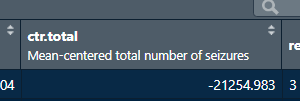

A Column Label in a Data Frame

## New Dog, Old Tricks

I’m going to grab some data from a (kinda) recent Warhammer tournament.

What is Warhammer, you ask? It’s a super fun miniature war game. Find out more at https://www.games-workshop.com/en-US/Home.

[figure not shown]

Warhammer

Anywho, a bunch of dudes got together and had a tournament. These data reflect the results of that tournament.

```r
warhammer <- read.csv("warhammer.csv",header=TRUE)
str(warhammer)
```

```
## 'data.frame':    39 obs. of  16 variables:
##  $ Name        : chr  "Timothy Travers" "Jeremy Veysseire" "Thomas Oakey" "Jack Gerlicher" ...
##  $ Rank        : int  1 2 2 4 5 5 5 8 8 10 ...
##  $ Score       : num  129.3 111.9 105.2 90 82.1 ...
##  $ Army        : chr  "Blood Angels" "Harlequins" "Adeptus Astartes" "Eldar" ...
##  $ Faction     : chr  "Space Marines" "Eldar" "Space Marines" "Eldar" ...
##  $ human.aliens: chr  "Humans" "Aliens" "Humans" "Aliens" ...
##  $ Game1Pts    : int  19 19 19 7 13 13 19 13 13 7 ...
##  $ Game1WL     : chr  "Win" "Win" "Win" "Loss" ...
##  $ Game2Pts    : int  19 19 19 13 1 19 19 10 10 19 ...
##  $ Game2WL     : chr  "Win" "Win" "Win" "Win" ...
##  $ Game3Pts    : int  13 19 7 19 13 7 1 7 7 13 ...
##  $ Game3WL     : chr  "Win" "Win" "Loss" "Win" ...
##  $ Game4Pts    : int  13 19 13 19 19 13 13 19 13 19 ...
##  $ Game4WL     : chr  "Win" "Win" "Win" "Win" ...
##  $ Game5Pts    : int  19 1 19 13 19 13 13 13 19 7 ...
##  $ Game5WL     : chr  "Win" "Loss" "Win" "Win" ...
```

```r
summary(warhammer)
```

```
##      Name                Rank           Score            Army
##  Length:39          Min.   : 1.00   Min.   : 33.74   Length:39
##  Class :character   1st Qu.:10.50   1st Qu.: 33.74   Class :character
##  Mode  :character   Median :20.00   Median : 44.99   Mode  :character
##                     Mean   :19.18   Mean   : 53.79
##                     3rd Qu.:27.00   3rd Qu.: 66.36
##                     Max.   :39.00   Max.   :129.35
##
##    Faction          human.aliens          Game1Pts        Game1WL
##  Length:39          Length:39          Min.   : 0.000   Length:39
##  Class :character   Class :character   1st Qu.: 4.000   Class :character
##  Mode  :character   Mode  :character   Median : 7.000   Mode  :character
##                                        Mean   : 9.744
##                                        3rd Qu.:13.000
##                                        Max.   :19.000
##
##     Game2Pts        Game2WL             Game3Pts        Game3WL
##  Min.   : 0.000   Length:39          Min.   : 0.000   Length:39
##  1st Qu.: 1.000   Class :character   1st Qu.: 1.000   Class :character
##  Median :10.000   Mode  :character   Median : 7.000   Mode  :character
##  Mean   : 9.744                      Mean   : 9.744
##  3rd Qu.:19.000                      3rd Qu.:16.000
##  Max.   :19.000                      Max.   :19.000
##
##     Game4Pts      Game4WL             Game5Pts        Game5WL
##  Min.   : 1.0   Length:39          Min.   : 1.000   Length:39
##  1st Qu.: 2.5   Class :character   1st Qu.: 7.000   Class :character
##  Median :10.0   Mode  :character   Median :10.000   Mode  :character
##  Mean   :10.0                      Mean   : 9.833
##  3rd Qu.:17.5                      3rd Qu.:13.000
##  Max.   :19.0                      Max.   :19.000
##  NA's   :1                         NA's   :3
```

### What the heck does this have to do with criminal justice?

**Nothing!**

But the data are really handy for showing some data manipulation techniques.

At the crux of the game, you have futuristic humans fighting aliens. So it might be a good idea to know whether the tournament participants were playing a **human** army or an **alien** army.

Because we have to nerd up the situation, players refer to the armies as *factions*, and factions can either be *Imperial* or *Xenos* factions

For our purposes…

- “Imperial” means “humans”
- “Xenos” means “aliens”

Notice that there is a variable in the data set called “Army”

```r
table(warhammer$Army)
```

```
##
##    Adeptus Astartes             Aeldari     Astra Militarum            Asuryani
##                   4                   1                   2                   1
##        Blood Angels        Chaos Demons Chaos Space Marines     Cult Mechanicus
##                   5                   1                   3                   2
##         Dark Angels               Eldar    Genestealer Cult          Harlequins
##                   1                   1                   1                   2
##    Imperial Knights            Maynarkh             Necrons                Orks
##                   1                   1                   2                   3
##        Space Wolves                 Tau            Tyranids        Ultramarines
##                   2                   2                   2                   1
##        World Eaters
##                   1
```

In total, **21** different factions were represented in this tournament. That’s a categorical variable, but it’s unwieldy. Let’s recode a new variable that just tells us whether the army played was Imperial or Xenos (human or alien).

The catch is that we’ll have to do this 21 times.

```r
human_alien <- vector()
length(human_alien) <- length(warhammer$Army)
human_alien[warhammer$Army=="Adeptus Astartes"]<-"Imperial"
human_alien[warhammer$Army=="Aeldari"]<-"Xenos"
human_alien[warhammer$Army=="Astra Militarum"]<-"Imperial"
human_alien[warhammer$Army=="Asuryani"]<-"Xenos"
human_alien[warhammer$Army=="Blood Angels"]<-"Imperial"
human_alien[warhammer$Army=="Chaos Demons"]<-"Xenos"
human_alien[warhammer$Army=="Chaos Space Marines"]<-"Xenos"
human_alien[warhammer$Army=="Cult Mechanicus"]<-"Imperial"
human_alien[warhammer$Army=="Dark Angels"]<-"Imperial"
human_alien[warhammer$Army=="Eldar"]<-"Xenos"
human_alien[warhammer$Army=="Genestealer Cult"]<-"Xenos"
human_alien[warhammer$Army=="Harlequins"]<-"Xenos"
human_alien[warhammer$Army=="Imperial Knights"]<-"Imperial"
human_alien[warhammer$Army=="Maynarkh"]<-"Xenos"
human_alien[warhammer$Army=="Necrons"]<-"Xenos"
human_alien[warhammer$Army=="Orks"]<-"Xenos"
human_alien[warhammer$Army=="Space Wolves"]<-"Imperial"
human_alien[warhammer$Army=="Tau"]<-"Xenos"
human_alien[warhammer$Army=="Tyranids"]<-"Xenos"
human_alien[warhammer$Army=="Ultramarines"]<-"Imperial"
human_alien[warhammer$Army=="World Eaters"]<-"Xenos"
table(human_alien)
```

```
## human_alien
## Imperial    Xenos
##       18       21
```

If you’re keeping score… I’m a Dark Angels player.

[figure not shown]

Dark Angels

Having gone to that trouble, I can add that new variable into my big data set.

```r
warhammer <- cbind(warhammer,human_alien)
```

### Then, I could ask a question like “Did Imperial or Xenos Armies do better in this tournament?”

```r
library(psych)
describeBy(warhammer$Score,warhammer$human_alien)
```

```
##
##  Descriptive statistics by group
## group: Imperial
##    vars  n  mean   sd median trimmed   mad   min    max range skew kurtosis
## X1    1 18 55.48 27.6  44.99   52.22 15.85 33.74 129.35 95.61 1.35     0.67
##      se
## X1 6.51
## ------------------------------------------------------------
## group: Xenos
##    vars  n  mean    sd median trimmed   mad   min    max range skew kurtosis
## X1    1 21 52.34 22.52  44.62   48.81 16.13 33.74 111.92 78.18 1.08     0.15
##      se
## X1 4.91
```

Looks like the Imperial forces did slightly better

*Purge the Xenos!!*

Sorry, force of habit.

### What about overall tournament rank?

```r
describeBy(warhammer$Rank, warhammer$human_alien)
```

```
##
##  Descriptive statistics by group
## group: Imperial
##    vars  n  mean    sd median trimmed  mad min max range skew kurtosis  se
## X1    1 18 18.11 11.02   18.5   17.88 8.15   1  39    38 0.19    -0.87 2.6
## ------------------------------------------------------------
## group: Xenos
##    vars  n mean    sd median trimmed   mad min max range  skew kurtosis   se
## X1    1 21 20.1 11.77     21   20.12 14.83   2  38    36 -0.01    -1.55 2.57
```

Again, Imperial Armies did better, since lower rank means better performance.

## Subsetting Data Frames

What if we want to perform analyses on only a portion of the data?

A simple solution would be to create a data frame that’s just a subset of the original one. That’s really easy to do with the **subset()** function.

### Subsetting on a single condition

Let’s say I only want to consider Imperial armies. I can create a new data frame (let’s call it *imperial* for the sake of originality) that only includes cases from the *warhammer* data frame in which the Army is an Imperial one.

```r
imperial <- subset(warhammer, warhammer$human_alien=="Imperial")
summary(imperial)
```

```
##      Name                Rank           Score            Army
##  Length:18          Min.   : 1.00   Min.   : 33.74   Length:18
##  Class :character   1st Qu.:11.75   1st Qu.: 37.96   Class :character
##  Mode  :character   Median :18.50   Median : 44.99   Mode  :character
##                     Mean   :18.11   Mean   : 55.48
##                     3rd Qu.:24.00   3rd Qu.: 63.55
##                     Max.   :39.00   Max.   :129.35
##
##    Faction          human.aliens          Game1Pts        Game1WL
##  Length:18          Length:18          Min.   : 0.000   Length:18
##  Class :character   Class :character   1st Qu.: 1.000   Class :character
##  Mode  :character   Mode  :character   Median : 7.000   Mode  :character
##                                        Mean   : 8.278
##                                        3rd Qu.:13.000
##                                        Max.   :19.000
##
##     Game2Pts       Game2WL             Game3Pts        Game3WL
##  Min.   : 0.00   Length:18          Min.   : 0.000   Length:18
##  1st Qu.: 7.00   Class :character   1st Qu.: 2.500   Class :character
##  Median :13.00   Mode  :character   Median :10.000   Mode  :character
##  Mean   :11.61                      Mean   : 9.278
##  3rd Qu.:19.00                      3rd Qu.:13.000
##  Max.   :19.00                      Max.   :19.000
##
##     Game4Pts        Game4WL             Game5Pts       Game5WL
##  Min.   : 1.000   Length:18          Min.   : 1.00   Length:18
##  1st Qu.: 1.000   Class :character   1st Qu.: 7.00   Class :character
##  Median :10.000   Mode  :character   Median :13.00   Mode  :character
##  Mean   : 9.333                      Mean   :10.53
##  3rd Qu.:13.000                      3rd Qu.:13.00
##  Max.   :19.000                      Max.   :19.00
##                                      NA's   :1
##  human_alien
##  Length:18
##  Class :character
##  Mode  :character
##
##
##
##
```

```r
str(imperial)
```

```
## 'data.frame':    18 obs. of  17 variables:
##  $ Name        : chr  "Timothy Travers" "Thomas Oakey" "David Johansen" "Shaun Sharp" ...
##  $ Rank        : int  1 2 5 5 11 14 15 15 18 19 ...
##  $ Score       : num  129.3 105.2 82.1 85.5 66.4 ...
##  $ Army        : chr  "Blood Angels" "Adeptus Astartes" "Space Wolves" "Ultramarines" ...
##  $ Faction     : chr  "Space Marines" "Space Marines" "Space Marines" "Space Marines" ...
##  $ human.aliens: chr  "Humans" "Humans" "Humans" "Humans" ...
##  $ Game1Pts    : int  19 19 13 19 13 1 1 13 7 7 ...
##  $ Game1WL     : chr  "Win" "Win" "Win" "Win" ...
##  $ Game2Pts    : int  19 19 1 19 19 19 13 13 10 10 ...
##  $ Game2WL     : chr  "Win" "Win" "Loss" "Win" ...
##  $ Game3Pts    : int  13 7 13 1 13 19 13 13 7 19 ...
##  $ Game3WL     : chr  "Win" "Loss" "Win" "Loss" ...
##  $ Game4Pts    : int  13 13 19 13 7 1 19 7 19 1 ...
##  $ Game4WL     : chr  "Win" "Win" "Win" "Win" ...
##  $ Game5Pts    : int  19 19 19 13 7 13 1 1 13 13 ...
##  $ Game5WL     : chr  "Win" "Win" "Win" "Win" ...
##  $ human_alien : chr  "Imperial" "Imperial" "Imperial" "Imperial" ...
```

### Subsetting on multiple conditions

You can also mix and match in the subset function.

If you want multiple conditions to be true (AND)…

This requires use of the **ampersand** operator

```r
# Imperial Armies with above the mean score
imperial_winners <- subset(warhammer,
                           warhammer$human_alien=="Imperial" &
                           warhammer$Score > 44.99)
str(imperial_winners)
```

```
## 'data.frame':    6 obs. of  17 variables:
##  $ Name        : chr  "Timothy Travers" "Thomas Oakey" "David Johansen" "Shaun Sharp" ...
##  $ Rank        : int  1 2 5 5 11 15
##  $ Score       : num  129.3 105.2 82.1 85.5 66.4 ...
##  $ Army        : chr  "Blood Angels" "Adeptus Astartes" "Space Wolves" "Ultramarines" ...
##  $ Faction     : chr  "Space Marines" "Space Marines" "Space Marines" "Space Marines" ...
##  $ human.aliens: chr  "Humans" "Humans" "Humans" "Humans" ...
##  $ Game1Pts    : int  19 19 13 19 13 13
##  $ Game1WL     : chr  "Win" "Win" "Win" "Win" ...
##  $ Game2Pts    : int  19 19 1 19 19 13
##  $ Game2WL     : chr  "Win" "Win" "Loss" "Win" ...
##  $ Game3Pts    : int  13 7 13 1 13 13
##  $ Game3WL     : chr  "Win" "Loss" "Win" "Loss" ...
##  $ Game4Pts    : int  13 13 19 13 7 7
##  $ Game4WL     : chr  "Win" "Win" "Win" "Win" ...
##  $ Game5Pts    : int  19 19 19 13 7 1
##  $ Game5WL     : chr  "Win" "Win" "Win" "Win" ...
##  $ human_alien : chr  "Imperial" "Imperial" "Imperial" "Imperial" ...
```

Or, maybe I want to quickly grab just the forces of Chaos…

So if the Army is Chaos Demons or Chaos Space Marines or World Eaters…

This will require the use of the **pipe** operator

```r
chaos <- subset(warhammer,
                warhammer$Army=="Chaos Demons" |
                warhammer$Army=="Chaos Space Marines" |
                warhammer$Army=="World Eaters")
str(chaos)
```

```
## 'data.frame':    5 obs. of  17 variables:
##  $ Name        : chr  "Logan Rourk" "Adam Solis" "Robert Winkler" "Seth Rourk" ...
##  $ Rank        : int  8 15 24 24 36
##  $ Score       : num  69.2 48.4 33.7 37.1 33.7
##  $ Army        : chr  "Chaos Space Marines" "Chaos Space Marines" "World Eaters" "Chaos Space Marines" ...
##  $ Faction     : chr  "Chaos" "Chaos" "Chaos" "Chaos" ...
##  $ human.aliens: chr  "Aliens" "Aliens" "Aliens" "Aliens" ...
##  $ Game1Pts    : int  13 13 7 19 1
##  $ Game1WL     : chr  "Win" "Win" "Loss" "Win" ...
##  $ Game2Pts    : int  10 1 1 1 19
##  $ Game2WL     : chr  "Draw" "Loss" "Loss" "Loss" ...
##  $ Game3Pts    : int  7 19 1 1 1
##  $ Game3WL     : chr  "Loss" "Win" "Loss" "Loss" ...
##  $ Game4Pts    : int  13 1 13 19 NA
##  $ Game4WL     : chr  "Win" "Loss" "Win" "Win" ...
##  $ Game5Pts    : int  19 13 19 1 NA
##  $ Game5WL     : chr  "Win" "Win" "Win" "Loss" ...
##  $ human_alien : chr  "Xenos" "Xenos" "Xenos" "Xenos" ...
```

## Where to go from here

There are lots of more advanced data cleaning functions

- apply()
- sapply()
- lapply()
- for{}
- ifelse()

Using them requires a more nuanced understanding of what you’re trying to do. The code we’ve walked through today will get you pretty much wherever you want to go on your data cleaning journey.

## The End

[figure not shown]

Does History Channel Have History Anymore?